# R: ggplot2 - First Steps

## 3.5 Other options

Many other functions are proposed by **ggplot**:

- **ggtitle** to add a title
- **ggsave** ta save a graph
- **theme_** to change the theme of the graph

```r
p <- ggplot(diamonds2)+aes(x=carat,y=price,color=cut)+geom_point()
p
```

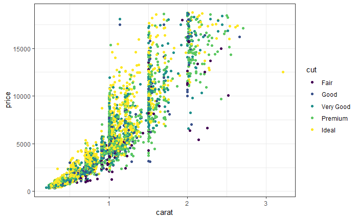

```r
p+theme_bw()
```

[figure not shown]

```r
p+theme_classic()
```

```r
p+theme_grey()
```

[figure not shown]

```r
p+theme_bw()
```

[figure not shown]

```r
p+theme_bw()+theme(legend.position="bottom")
```

# 4 Go deeper in geom_ parameters

We consider the dataset **mtcars**

```r
data(mtcars)
summary(mtcars)
```

```
      mpg             cyl             disp             hp             drat             wt             qsec             vs
 Min.   :10.40   Min.   :4.000   Min.   : 71.1   Min.   : 52.0   Min.   :2.760   Min.   :1.513   Min.   :14.50   Min.   :0.0000
 1st Qu.:15.43   1st Qu.:4.000   1st Qu.:120.8   1st Qu.: 96.5   1st Qu.:3.080   1st Qu.:2.581   1st Qu.:16.89   1st Qu.:0.0000
 Median :19.20   Median :6.000   Median :196.3   Median :123.0   Median :3.695   Median :3.325   Median :17.71   Median :0.0000
 Mean   :20.09   Mean   :6.188   Mean   :230.7   Mean   :146.7   Mean   :3.597   Mean   :3.217   Mean   :17.85   Mean   :0.4375
 3rd Qu.:22.80   3rd Qu.:8.000   3rd Qu.:326.0   3rd Qu.:180.0   3rd Qu.:3.920   3rd Qu.:3.610   3rd Qu.:18.90   3rd Qu.:1.0000
 Max.   :33.90   Max.   :8.000   Max.   :472.0   Max.   :335.0   Max.   :4.930   Max.   :5.424   Max.   :22.90   Max.   :1.0000
       am              gear            carb
 Min.   :0.0000   Min.   :3.000   Min.   :1.000
 1st Qu.:0.0000   1st Qu.:3.000   1st Qu.:2.000
 Median :0.0000   Median :4.000   Median :2.000
 Mean   :0.4062   Mean   :3.688   Mean   :2.812
 3rd Qu.:1.0000   3rd Qu.:4.000   3rd Qu.:4.000
 Max.   :1.0000   Max.   :5.000   Max.   :8.000
```

```r
#help(mtcars)
```

## 4.1 Histogram

### 4.1.1 Bins

Drawing the histogram of **mpg** (using many numbers of bins):

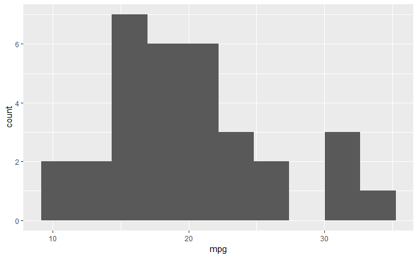

```r
ggplot(mtcars)+aes(x=mpg)+geom_histogram(bins=10)
```

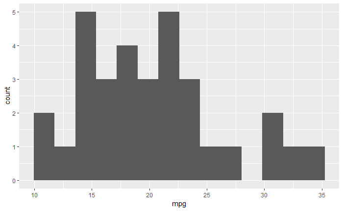

```r
ggplot(mtcars)+aes(x=mpg)+geom_histogram(bins=14)
```

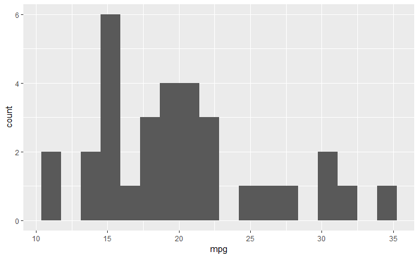

```r
ggplot(mtcars)+aes(x=mpg)+geom_histogram(bins=18)
```

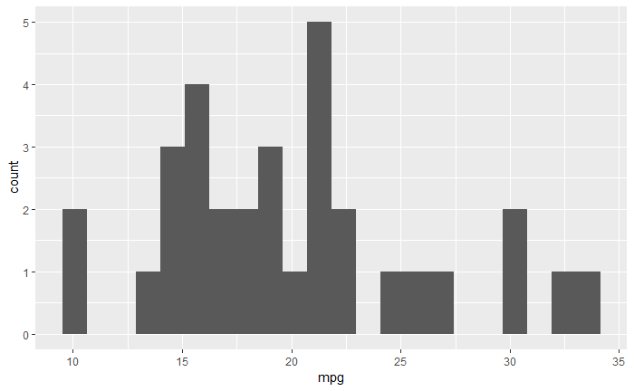

```r
ggplot(mtcars)+aes(x=mpg)+geom_histogram(bins=22)
```

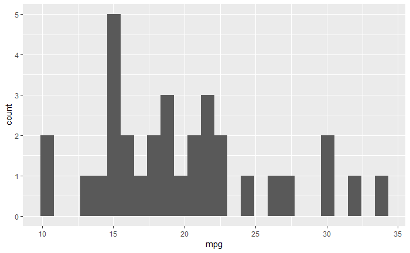

```r
ggplot(mtcars)+aes(x=mpg)+geom_histogram(bins=26)
```

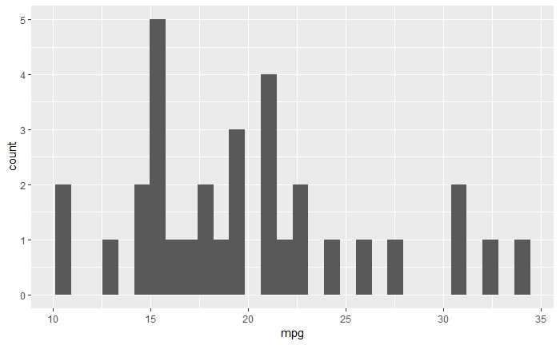

```r
ggplot(mtcars)+aes(x=mpg)+geom_histogram(bins=30)
```

### 4.1.2 Density

Represent the density on the $y$-axis.

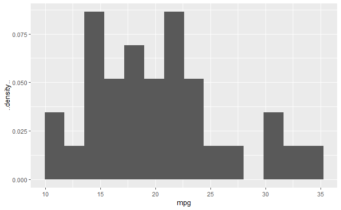

```r
ggplot(mtcars)+aes(x=mpg,y=..density..)+geom_histogram(bins=14)
```

## 4.2 Barplot

Drawing the barplot of **cyl**:

### 4.2.1 Quantitative

By default *stat=“count”*:

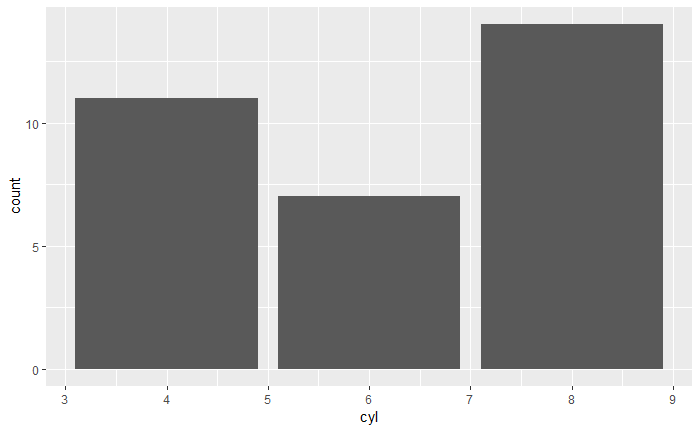

```r
ggplot(mtcars)+aes(x=cyl,fill=cyl)+geom_bar()
```

### 4.2.2 1 factor

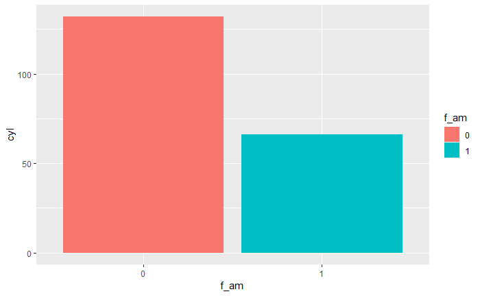

```r
mtcars$f_am <- as.factor(mtcars$am)
ggplot(mtcars)+aes(x=f_am,y=cyl, fill=f_am)+geom_bar(stat="identity")
```

### 4.2.3 2 factors

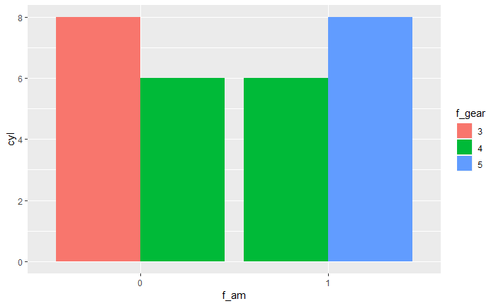

```r
mtcars$f_gear <- as.factor(mtcars$gear)
ggplot(data=mtcars) +
  aes(x=f_am, y=cyl, fill=f_gear) +
  geom_bar(stat="identity", position=position_dodge())
```

### 4.2.4 Stacked barplot

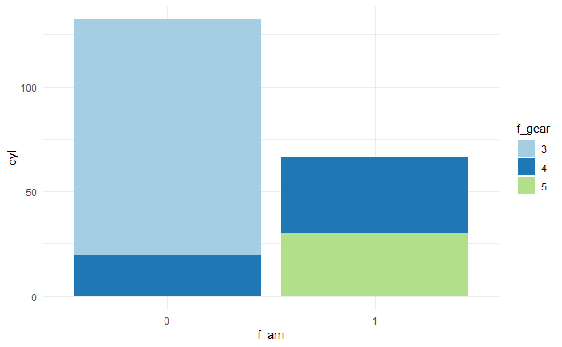

```r
ggplot(data=mtcars) +
  aes(x=f_am, y=cyl, fill=f_gear) +
  geom_bar(stat="identity") +
  scale_fill_brewer(palette="Paired")+
  theme_minimal()
```

## 4.3 Scatterplot

### 4.3.1 Facets

Drawing the scatter plot **disp vs mpg** for each value of **cyl** (one color for each value of **cyl**).

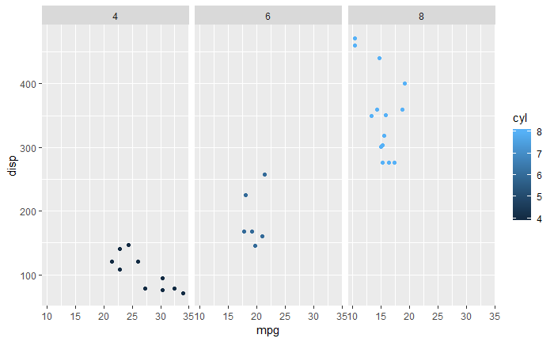

```r
ggplot(mtcars)+aes(x=mpg,y=disp,color=cyl)+geom_point()+facet_wrap(~cyl)
```

### 4.3.2 Smooth

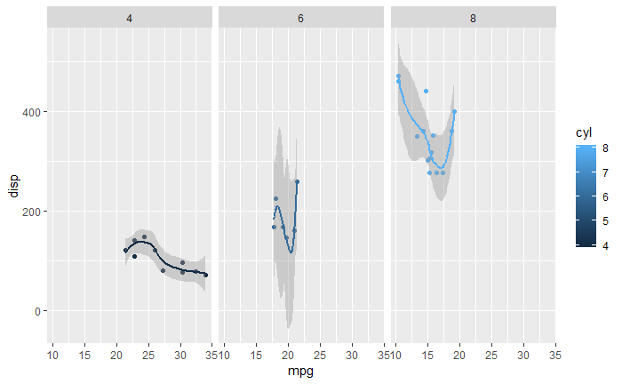

```r
g1 <- ggplot(mtcars)+aes(x=mpg,y=disp,color=cyl)+geom_point()+geom_smooth(method="loess")+facet_wrap(~cyl)
g1
```

## 4.4 Segment

Here’s an other example:

Let’s simulate a sample $(x_i,y_i),i=1,\dots,100$ according to the linear model
$$Y_i=3+X_i+\varepsilon_i$$
where $X_i$ are i.i.d. and uniform on $[0,1]$ and $\varepsilon_i$ are gaussian $N(0,0.2^2)$ (use **runif** and **rnorm**).

```r
set.seed(123)
X <- runif(100,0,1)
epsilon <- rnorm(100,0,0.2)
#help(rnorm)
Y <- 3+X+epsilon
data <- data.frame(X,Y)
```

Drawing the scatter plot **y vs x** and add the linear smoother.

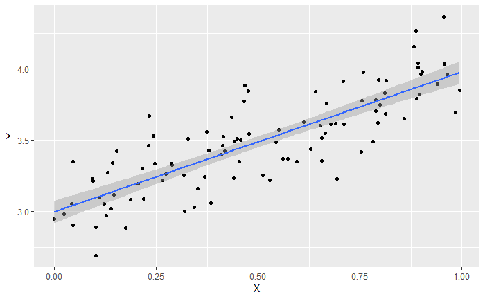

```r
ggplot(data)+aes(x=X,y=Y)+geom_point()+geom_smooth(method="lm")
```

Drawing the residuals: add a vertical line from each point to the linear smoother (use **geom_segment**).

```r
regression <- lm(Y~X,data=data)
regression
```

```
Call:
lm(formula = Y ~ X, data = data)

Coefficients:
(Intercept)            X
      2.998        0.982
```

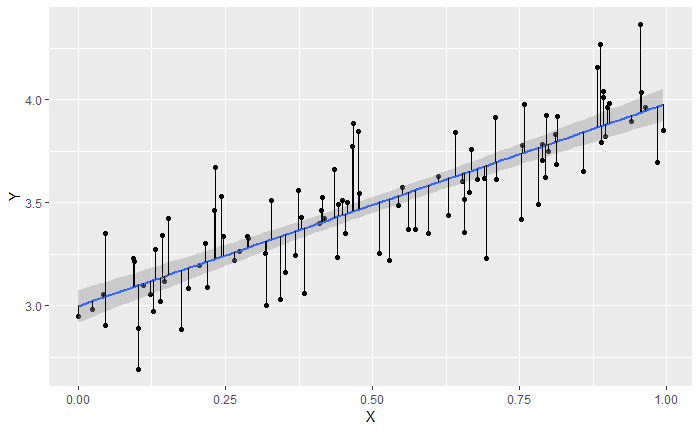

```r
residus <- residuals(regression)
data1 <- cbind(data,residus)
Yhat <- data1$Y-data1$residus
new_data <- cbind.data.frame(data1,Yhat)
# for (i in (1:100)){
#   geom_segment(aes(x=new_data[i,][1],y=new_data[i,][2],xend=new_data[i,][1],yend=new_data[i,][4]))
# }
# ggplot(data)+aes(x=X,y=Y)+geom_point()+geom_smooth(method="lm")+(for (i in (1:100)){geom_segment(aes(x=new_data[i,][1],y=new_data[i,][2],xend=new_data[i,][1],yend=new_data[i,][4]))
# })
ggplot(data)+aes(x=X,y=Y)+geom_point()+geom_smooth(method="lm")+geom_segment(aes(x=new_data$X,y=new_data$Yhat,xend=new_data$X,yend=new_data$Y))
```

# 5 Use case : ROC curve

ROC curve is a visualization tool which allows to measure the performance of a **score** for a binary classification problem. Assume we want to explain a binary variable $Y$ (-1 or 1) by $p$ inputs $X_1,\dots,X_p$. A score is a function $\mathbb R^p\to\mathbb R$ such that $S(x)$ should be

- large if we think that $x$ is +1
- small if we think that $x$ is -1.

We can measure the performance of a score function by the 2 errors
$$\alpha(s)=P(g_s(X)=1|Y=-1)=P(S(X)\geq s|Y=-1)$$
and
$$\beta(s)=P(g_s(X)=-1|Y=1)=P(S(X)<s|Y=1).$$
The ROC curve allows to visualize these two errors on a same graph. It is defined by
$$\left\{
\begin{array}{l}
x(s)=\alpha(s)=1-sp(s)=P(S(X)>s|Y=-1) \\
y(s)=1-\beta(s)=se(s)=P(S(X)\geq s|Y=1)
\end{array}\right.$$
In practice the roc curve is unknown and should be estimated from a sample $(X_1,Y_1),\dots,(X_n,Y_n)$.

1. We consider two score functions $S_1$ and $S_2$. Values of these two scores functions as well as observed output are provided by the following commands:

```r
n <- 200
set.seed(1234)
S1 <- runif(n)
set.seed(5678)
S2 <- runif(n)
Y <- rep(0,n)
Y[S1>0.55] <- 1
df <- data.frame(S1,S2,Y=as.factor(Y))
```

We represent value of the score according to the output with the following command

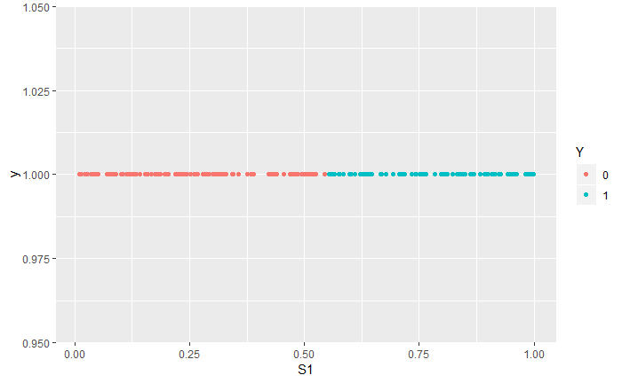

```r
ggplot(df)+geom_point(aes(x=S1,y=1,color=Y))
```

To add on the graph values of $S_2$, we can represent them on the value 2 of the $y$-axis.

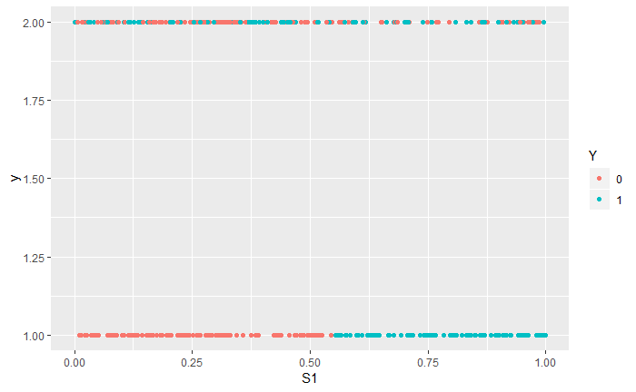

```r
ggplot(df)+geom_point(aes(x=S1,y=1,color=Y))+geom_point(aes(x=S2,y=2,color=Y))
```

The first score seems more consistent in the sense that the observations are better separated!

2. *geom_roc* function from the **plotROC** package allows to draw roc curves. For instance, we can represent ROC curve of $S_1$ with

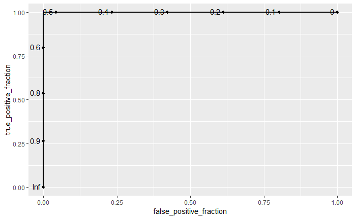

```r
library(plotROC)
df$Y <- as.numeric(Y)
g <- ggplot(df)+aes(m=S1,d=Y)+geom_roc()
g
```

To add on the graph the ROC curve on $S_2$ we can use **gather**.

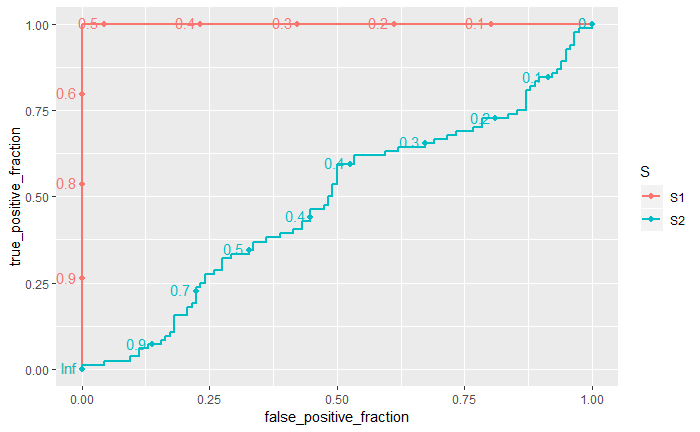

```r
df_new <- gather(df,key="S",values=c("S1","S2"))
#new_data <- gather(data=data,key="func",values="value",-X)
#g+geom_roc(aes(m=S2,d=Y))
#ggplot(new_data)+aes(x=X,y=value,colour=fonction)+geom_line()
g <- ggplot(df_new)+aes(m=value,d=Y,color=S)+geom_roc()
g
```

# 6 Boxplots

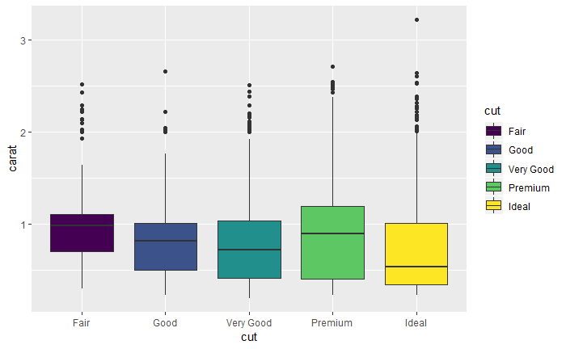

```r
#help(mtcars)
ggplot(diamonds2)+aes(x=cut,y=carat,fill=cut)+geom_boxplot()
```

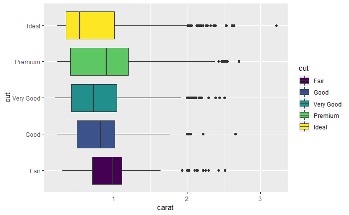

```r
#help(coord_flip)
ggplot(diamonds2)+aes(x=cut,y=carat,fill=cut)+geom_boxplot()+coord_flip()
```

Using the **ggstance** package to add percentiles.

```r
library(ggstance)
```

### 6.0.1 Adding quantiles and facets

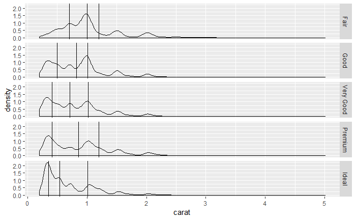

```r
quantile <- diamonds %>%
  group_by(cut) %>%
  summarise(Q1=quantile(carat,0.25),
            Q2=quantile(carat,0.5),
            Q3=quantile(carat,0.75),
  )
quantile_new <- gather(data=quantile,key="Q",values=c("Q1","Q2","Q3"))
ggplot(diamonds)+geom_density(aes(x=carat,y=..density..))+facet_grid(cut~.)+geom_vline(data=quantile_new,aes(xintercept=value))
```

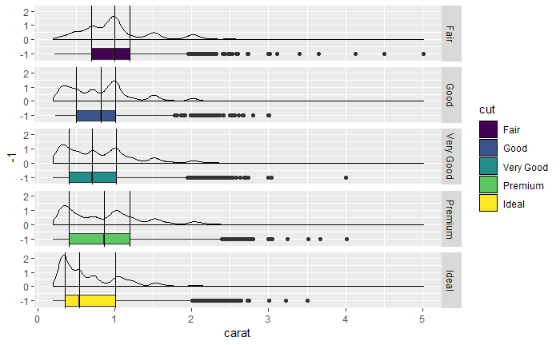

```r
ggplot(diamonds)+geom_boxploth(aes(x=carat,y=-1,fill=cut))+facet_grid(cut~.)+geom_density(aes(x=carat,y=..density..))+geom_vline(data=quantile_new,aes(xintercept=value))+facet_grid(cut~.)
```

Or by using *geom_vline()*

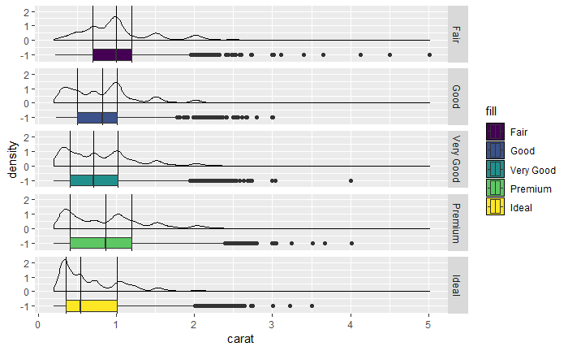

```r
ggplot(diamonds)+geom_density(aes(x=carat,y=..density..))+geom_vline(data=quantile_new,aes(xintercept=value))+geom_boxploth(aes(x=carat,y=-1,fill=cut))+facet_grid(cut~.)
```